# Tugas Kelompok 2

Kelompok S

2023-09-26

Nama Kelompok :

- Andreas Hendra Herwanto (164221064)
- Fabyan Riza Kiram (164221068)
- Octaviani Putri Al Fajri (164221042)

## Data Source

https://www.kaggle.com/datasets/ibrahimelsayed182/plane-ticket-price

## Data Description

1 . ID: Contiguous sample number

2 . Airline: The name of the airline

3 . DateofJourney: The date of the journey

4 . Source: The source from which the service begins

5 . Destination: The destination where the service ends

6 . Dep_Time: The time when the journey starts from the source.

7 . Arrival_Time: Time of arrival at the destination.

8 . Duration: Total duration of the flight.

9 . Total_Stops: Total stops between the source and destination.

10 . Additional_Info: Additional information about the flight

11 . Price: The price of the ticket

## Import Data

```r
setwd("D:/KULIAH/Tugas/SEMESTER 3/EVD")

library(readr)
df=read_csv("plane.csv")
head(df)
```

| Airline | Date_of_Journey | Source | Destination | Route | Dep_Time | Arrival_Time | Duration | Duration(Hour) | Total_Stops | Additional_Info | Price(Rupee) |
| --- | --- | --- | --- | --- | --- | --- | --- | --- | --- | --- | --- |
| IndiGo | 24/03/2019 | Banglore | New Delhi | BLR ? DEL | 22:20:00 | 3/22/2023 1:10 | 2h 50m | 2.83 | 0 | No Info | 3897 |
| Air India | 1/5/2019 | Kolkata | Banglore | CCU ? IXR ? BBI ? BLR | 05:50:00 | 13:15 | 7h 25m | 7.42 | 2 | No Info | 7662 |
| Jet Airways | 9/6/2019 | Delhi | Cochin | DEL ? LKO ? BOM ? COK | 09:25:00 | 6/10/2023 4:25 | 19h | 19.00 | 2 | No Info | 13882 |
| IndiGo | 12/5/2019 | Kolkata | Banglore | CCU ? NAG ? BLR | 18:05:00 | 23:30 | 5h 25m | 5.42 | 1 | No Info | 6218 |
| IndiGo | 1/3/2019 | Banglore | New Delhi | BLR ? NAG ? DEL | 16:50:00 | 21:35 | 4h 45m | 4.75 | 1 | No Info | 13302 |
| SpiceJet | 24/06/2019 | Kolkata | Banglore | CCU ? BLR | 09:00:00 | 11:25 | 2h 25m | 2.42 | 0 | No Info | 3873 |

## Variabel Selection

```r
library(dplyr)
df_clear<-select(df,-c("Date_of_Journey","Route","Dep_Time","Arrival_Time","Duration","Additional_Info"))
head(df_clear)
```

| Airline | Source | Destination | Duration(Hour) | Total_Stops | Price(Rupee) |
| --- | --- | --- | --- | --- | --- |
| IndiGo | Banglore | New Delhi | 2.83 | 0 | 3897 |
| Air India | Kolkata | Banglore | 7.42 | 2 | 7662 |
| Jet Airways | Delhi | Cochin | 19.00 | 2 | 13882 |
| IndiGo | Kolkata | Banglore | 5.42 | 1 | 6218 |
| IndiGo | Banglore | New Delhi | 4.75 | 1 | 13302 |
| SpiceJet | Kolkata | Banglore | 2.42 | 0 | 3873 |

## Checking Missing Value

```r
missing_values_per_column <- colSums(is.na(df_clear))
missing_values_per_column
```

```
##        Airline         Source    Destination Duration(Hour)    Total_Stops
##              0              0              0              0              0
##   Price(Rupee)
##              0
```

## Label Encoding

```r
library(CatEncoders)
df_encoding<-data.frame(df_clear)

labs1 = LabelEncoder.fit(df_encoding$Airline)
labs2 = LabelEncoder.fit(df_encoding$Source)
labs3 = LabelEncoder.fit(df_encoding$Destination)

df_encoding$Airline <- transform(labs1, df_encoding$Airline)
df_encoding$Source <- transform(labs2, df_encoding$Source)
df_encoding$Destination <- transform(labs3, df_encoding$Destination)

df_encoding
```

| Airline | Source | Destination | Duration.Hour. | Total_Stops | Price.Rupee. |
| --- | --- | --- | --- | --- | --- |
| 4 | 1 | 6 | 2.83 | 0 | 3897 |
| 2 | 4 | 1 | 7.42 | 2 | 7662 |
| 5 | 3 | 2 | 19.00 | 2 | 13882 |
| 4 | 4 | 1 | 5.42 | 1 | 6218 |
| 4 | 1 | 6 | 4.75 | 1 | 13302 |
| 9 | 4 | 1 | 2.42 | 0 | 3873 |
| 5 | 1 | 6 | 15.50 | 1 | 11087 |
| 5 | 1 | 6 | 21.08 | 1 | 22270 |
| 5 | 1 | 6 | 25.50 | 1 | 11087 |
| 7 | 3 | 2 | 7.83 | 1 | 8625 |

[output cut: 9990 more lines]

## Correlation Table

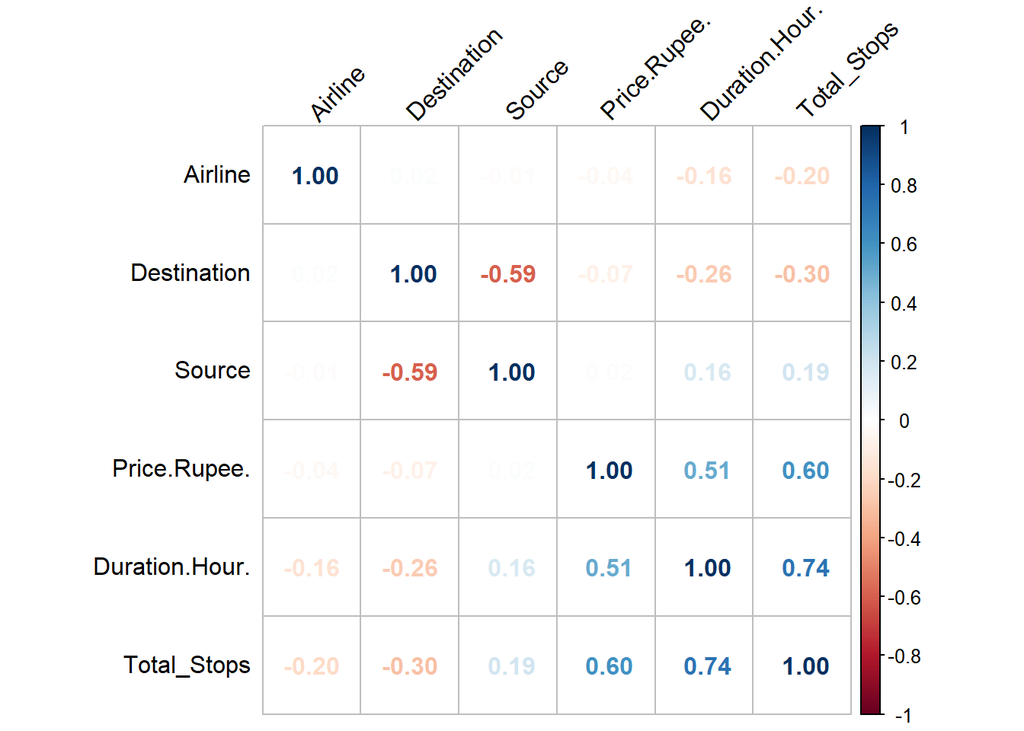

```r
library(corrplot)
corrplot(cor(df_encoding),
         order = "hclust",
         tl.col="black",
         tl.srt=45,
         method = "number")
```

**Keterangan :**

- Nilai korelasi negatif : Kedua variabel memiliki hubungan yang berlawanan.
- Nilai korelasi positif : Kedua variabel memiliki hubungan yang searah.
- Nilai korelasi antara 0 – 0,25 : Korelasi sangat lemah
- Nilai korelasi antara 0,25 – 0,5 : Korelasi cukup
- Nilai korelasi antara 0,5 – 0,75 : Korelasi kuat
- Nilai korelasi antara 0,75 – 0,99 : Korelasi sangat kuat
- Nilai korelasi antara 1 atau -1 : Korelasi hubungan sempurna

## EDA

```r
library(dplyr)
library(ggplot2)
library(ggrepel)
```

1. Proporsi Jumlah Tiket dari Setiap Maskapai

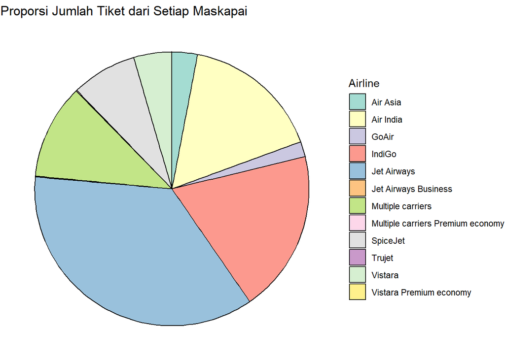

```r
plotdata<-df %>%
  count(Airline) %>%
  arrange(desc(Airline)) %>%
  mutate(prop = round(n*100/sum(n),1),
         lab.ypos=cumsum(prop)-0.5*prop)

ggplot(plotdata,aes(x="",y=prop, fill=Airline))+
  geom_bar(width=1,
           stat="identity",
           color="black",
           alpha=0.8)+
  coord_polar('y', start=0,
              direction=-1)+
  theme_void()+
  labs(title= "Proporsi Jumlah Tiket dari Setiap Maskapai")+
  theme(plot.title = element_text(hjust = 0.8, vjust=-5))+
  theme_void()+
  scale_fill_brewer(palette = "Set3")
```

2. Source dan Destinasi Penerbangan di India selama 2019

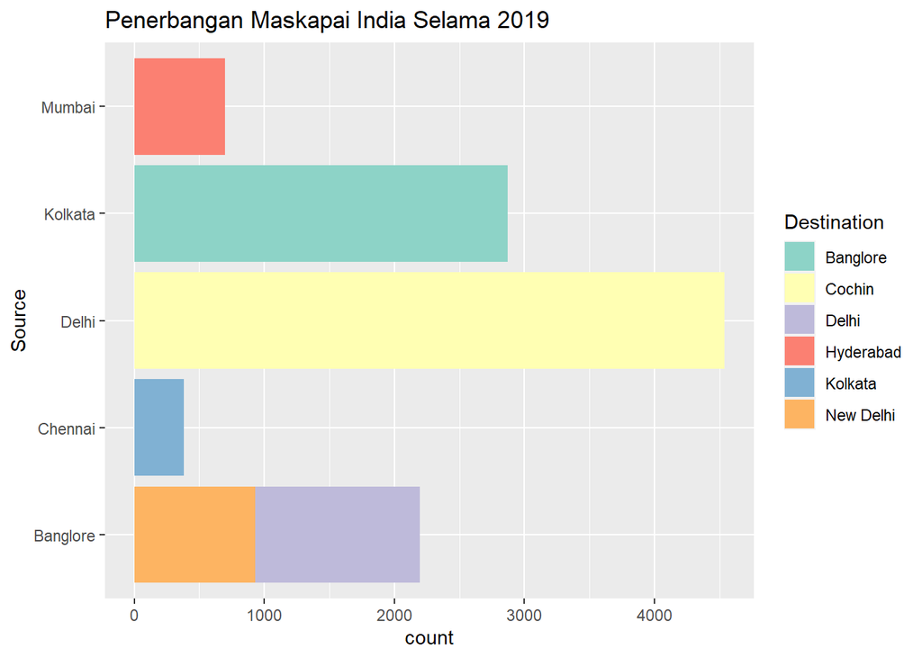

```r
ggplot(df, aes(y=Source, fill=Destination))+
  geom_bar()+
  labs(title="Penerbangan Maskapai India Selama 2019")+
  scale_fill_brewer(palette = "Set3")
```

3. Density Variabel Dependen (Price(Rupee))

[figure not shown]

```r
a<-ggplot(df, aes(`Price(Rupee)`))+
  geom_histogram(aes(y = ..density..),
                 fill = "#EEDD82",
                 alpha=0.8)+
  geom_density(color='black',lwd=0.5)+
  labs(title="Distribusi Biaya Asuransi (Charges)")+
  theme(plot.title = element_text(hjust = 0.8))

b<-ggplot (df, aes(y=`Price(Rupee)`)) +
  geom_boxplot (fill = "#EEDD82",
                alpha = 0.6,
                outlier.size=2,
                varwidth=TRUE) +
  labs (title = "Charges distribution")


library(gridExtra)
grid.arrange(a, b, ncol = 2)
```

4. Trend Harga Tiket Maskapai di India selama 2019

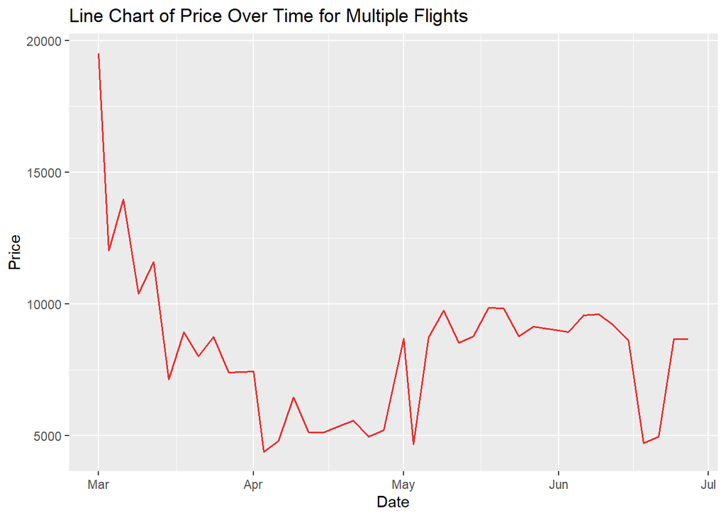

```r
data <- data.frame(
  Date = as.Date(df$Date_of_Journey, "%d/%m/%Y"),
  Price = df$`Price(Rupee)`)

test = aggregate(`Price(Rupee)`~Date_of_Journey,df,mean)

# Create a line chart with multiple lines (one line per flight)
ggplot(test, aes(x = as.Date(Date_of_Journey, "%d/%m/%Y"), y = `Price(Rupee)`))+
  geom_line(lwd=0.6, color="#EE2C2C") +
  labs(
    title = "Line Chart of Price Over Time for Multiple Flights",
    x = "Date",
    y = "Price")
```

5. Plot Price vs Total Stops and Price vs Duration (Hour)

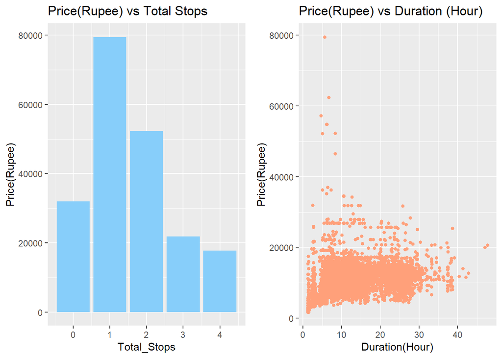

```r
plotdata5 <- df%>%
  group_by(Total_Stops)%>%
  summarize(max=max(`Price(Rupee)`))

a1<-ggplot(plotdata5, aes(x=Total_Stops, y=max))+
  geom_bar(stat="identity", fill="lightskyblue")+
  labs(title="Price(Rupee) vs Total Stops",
       y= "Price(Rupee)")

b1<-ggplot(df, aes(x=`Duration(Hour)`, y=`Price(Rupee)`))+
  geom_point(color="#FFA07A", size=1.3)+
  labs(title="Price(Rupee) vs Duration (Hour)")

library(gridExtra)
grid.arrange(a1, b1, ncol = 2)
```

6. Perbadingan Harga Setiap Maskapai

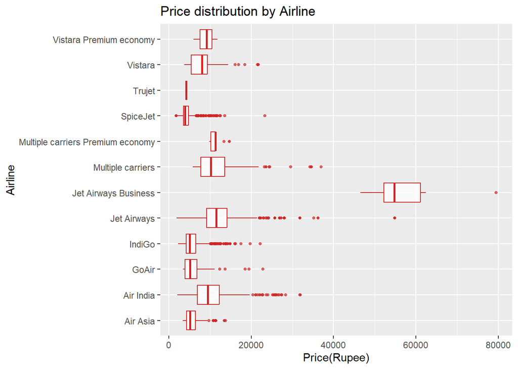

```r
ggplot(df,aes(x=`Price(Rupee)`,y=Airline))+
  geom_boxplot(alpha=.7,  outlier.size=1, color="#CD2626")+
  labs(title = "Price distribution by Airline")
```